# Jupyter Notebooks & Python Tutorial

Shawn Rhoads, Georgetown University (NSCI 526)

This tutorial has been adapted from the following resources on Jupyter Notebooks and Python:

- Luke Chang's [DartBrains](https://dartbrains.org)
- Adam Pritchard's [Markdown Cheatsheet](https://github.com/adam-p/markdown-here/wiki/Markdown-Cheatsheet)
- Eshin Jolly's [Jupyter Tutorial](https://github.com/Summer-MIND/mind_2018/tree/master/tutorials/jupyter)
- [NumPy Quickstart Tutorial](https://numpy.org/devdocs/user/quickstart.html)

## Interactive Coding!

We will use Jupyter Notebooks to interface with Python. Rather than keeping code scripts code and execution separate, jupyter integrates both together using the concept of cells. Two main types of cells are **code cells** and **markdown cells**. Cells pair "snippets" of code with the output obtained from running them and can contain plots/figure inline alongside code required to generate them

**Markdown cells** contain text. The text is written in markdown, a lightweight markup language. You can read about its syntax [here](https://daringfireball.net/projects/markdown/syntax). Note that you can also insert HTML into markdown cells, and this will be rendered properly. As you are typing the contents of these cells, the results appear as text. Hitting "shift + enter" renders the text in the formatting you specify. You can specify a cell as being a markdown cell in the Jupyter toolbar, or by hitting "esc, m" in the cell. Again, you have to hit enter after using the quick keys to bring the cell into edit mode.

In general, when you want to add a new cell, you can use the "Insert" pulldown menu from the Jupyter toolbar. The shortcut to insert a cell below is "esc, b" and to insert a cell above is "esc, a." Alternatively, you can execute a cell and automatically add a new one below it by hitting "alt + enter."

```python
# This is a code cell
#Put some code here and get some output below!
x = 10
print(x)
```

```
10
```

This is a *markdown* **cell**!

## Notebooks of the Future

Not just for code:

- Markdown, HTML, LateX integration
- Slide shows (like this one!)
- Keep your notes alongside your analysis routines
- Embed images, videos, anything (it's all just HTML + javascript)

### HTML Integration:

| **Var1** | **Var2** |
| --- | --- |
| Cell 1 | Cell 2 |
| Cell 3 | Cell 4 |

### LaTeX Integration:

Compute the following:
$$\sum_{n=1}^{5}n$$

### Inserting images from web:

```python
from IPython.display import display, Image

display(Image('https://raw.githubusercontent.com/Summer-MIND/mind_2018/master/tutorials/jupyter/demo.gif'))
```

[output not shown]

### Multilingual!

- Python (multiple versions together)
- R
- Matlab
- Javascript
- etc (https://github.com/jupyter/jupyter/wiki/Jupyter-kernels)

#### Coding with R:

`!conda install rpy2`

```python
import rpy2.rinterface
%load_ext rpy2.ipython
```

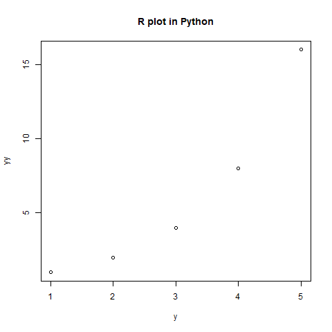

```python
%%R

y <- c(1,2,3,4,5)
yy <- c(1,2,4,8,16)

plot(y,
     yy,
     main='R plot in Python')
```

We will import `x=10` from above, define a variable `z<-10` in R, store their product into `XZ`, and then output a variable `XZ`

```python
%%R -i x -o XZ

z <- 10
XZ <- x * z
```

The cell below will return `XZ` in Python! Cool, huh?!

```python
print(XZ)
```

```
[1] 100
```

You can do this with other languages as well! e.g., MATLAB (because we like paying for licenses)

### Save notebooks in other formats and put them online

- Github automatically renders jupyter notebooks
- [Online notebook viewer](http://nbviewer.jupyter.org/)
- Output to PDF, HTML (including javascript)
- [Jupyterhub](https://github.com/jupyterhub/jupyterhub): code with friends!

### Customize your notebook experience with extensions

- Table of Contents
- Execution time/Profiling
- Scratch Space
- Code/Section folding
- Look and feel (CSS+Javascript)
- Other notebook extensions

### For more...

- [Eshin Jolly - Intro to Jupyter Notebooks](https://github.com/Summer-MIND/mind_2018/tree/master/tutorials/jupyter)
- [Jake Vanderplas - Data Science Handbook](https://github.com/jakevdp/PythonDataScienceHandbook)
- [Tal Yarkoni - Intro to Data Science w/ Python](https://github.com/tyarkoni/SSI2016)
- [Yaroslav Halchenko - Intro to Programming for Psych/Neuro](https://github.com/dartmouth-pbs/psyc161)
- [Awesome notebooks](https://github.com/jupyter/jupyter/wiki/A-gallery-of-interesting-Jupyter-Notebooks)
- [Neuroimaging in Python](https://github.com/datacarpentry/python-neuroimaging-lesson)
- [Google Colaboratory](https://colab.research.google.com/notebooks/welcome.ipynb#recent=true)

## Types of Variables

- Numeric types:
  - int, float, long, complex
- string
- boolean
  - True / False

Use the `type()` function to find the type for a value or variable

```python
# Integer
a = 1
print(type(a))

# Float
b = 1.0
print(type(b))

# String
c = 'hello'
print(type(c))

# Boolean
d = True
print(type(d))

# None
e = None
print(type(e))

# Cast integer to string
print(type(str(a)))
```

```
<class 'int'>
<class 'float'>
<class 'str'>
<class 'bool'>
<class 'NoneType'>
<class 'str'>
```

## Math Operators

- +, -, *, and /
- Exponentiation **
- Modulo %

```python
# Addition
a = 2 + 7
print(a)

# Subtraction
b = a - 5
print(b)

# Multiplication
print(b*2)

# Exponentiation
print(b**2)

# Modulo
print(4%9)

# Division
print(4/9)
```

```
9
4
8
16
4
0.4444444444444444
```

## String Operators

Some of the arithmetic operators also have meaning for strings. E.g. for string concatenation use + sign

String repetition: Use * sign with a number of repetitions

```python
# Combine string
a = 'Hello'
b = 'World'
print(a + b)

# Repeat String
print(a*5)
```

```
HelloWorld
HelloHelloHelloHelloHello
```

## Logical Operators

Perform logical comparison and return Boolean value

```
x == y # x is equal to y
x != y # x is not equal to y
x > y # x is greater than y
x < y # x is less than y
x >= y # x is greater than or equal to y
x <= y # x is less than or equal to y
```

```python
# Works for string
a = 'hello'
b = 'world'
c = 'Hello'
print("a==b: " + str(a==b))
print("a==c: " + str(a==c))
print("a!=b: " + str(a!=b))

# Works for numeric
d = 5
e = 8
print("d < e: " + str(d < e))
```

```
a==b: False
a==c: False
a!=b: True
d < e: True
```

## Conditional Logic (if…)

Unlike most other languages, Python uses tab formatting rather than closing conditional statements (e.g., end)

Syntax:

```
if condition:
    do something
```

Implicit conversion of the value to bool() happens if condition is of a different type than bool, thus all of the following should work:

```
if condition:
    do_something
elif condition:
    do_alternative1
else:
    do_otherwise # often reserved to report an error
                 # after a long list of options
```

```python
n = 1

if n:
    print("n is non-0")

if n is None:
    print("n is None")

if n is not None:
    print("n is not None")
```

```
n is non-0
n is not None
```

## Loops

**for** loop is probably the most popular loop construct in Python:

```
for target in sequence:
    do_statements
```

```python
string = "Python is going to make conducting research easier"
for c in string:
    print(c)
```

```
P
y
t
h
o
n

i
s

g
o
i
n
g

t
o

m
a
k
e

c
o
n
d
u
c
t
i
n
g

r
e
s
e
a
r
c
h

e
a
s
i
e
r
```

It’s also possible to use a **while** loop to repeat statements while condition remains True:

```
while condition do:
    do_statements
```

```python
x = 0
end = 10

csum = 0
while x < end:
    csum += x
    print(x, csum)
    x += 1
print("Exited with x==%d" % x )
```

```
0 0
1 1
2 3
3 6
4 10
5 15
6 21
7 28
8 36
9 45
Exited with x==10
```

## Functions

A **function** is a named sequence of statements that performs a computation. You define the function by giving it a name, specify a sequence of statements, and optionally values to return. Later, you can “call” the function by name.

```python
def make_upper_case(text):
    return (text.upper())
```

- The expression in the parenthesis is the **argument**.
- It is common to say that a function **"takes" an argument** and **"returns" a result**.
- The result is called the **return value**.

The first line of the function definition is called the header; the rest is called the body.

The header has to end with a colon and the body has to be indented. It is a common practice to use 4 spaces for indentation, and to avoid mixing with tabs.

Function body in Python ends whenever statement begins at the original level of indentation. There is no end or fed or any other identify to signal the end of function. Indentation is part of the the language syntax in Python, making it more readable and less cluttered.

```python
string = "Python is going to make conducting research easier"

print(make_upper_case(string))
```

```
PYTHON IS GOING TO MAKE CONDUCTING RESEARCH EASIER
```

## Python Containers

There are 4 main types of builtin containers for storing data in Python:

- list
- tuple
- dict
- set

### Lists

In Python, a list is a mutable sequence of values. Mutable means that we can change separate entries within a list.

- Each value in the list is an element or item
- Elements can be any Python data type
- Lists can mix data types
- Lists are initialized with [] or list()

  ```
  l = [1,2,3]
  ```

- Elements within a list are indexed (starting with 0)

  ```
  l[0]
  ```

- Elements can be nested lists

  ```
  nested = [[1, 2, 3], [4, 5, 6], [7, 8, 9]]
  ```

- Lists can be sliced.

  ```
  l[start:stop:stride]
  ```

- Like all python containers, lists have many useful methods that can be applied

  ```
  a.insert(index,new element)
  a.append(element to add at end)
  len(a)
  ```

- List comprehension is a very powerful technique allowing for efficient construction of new lists.

  ```
  [a for a in l]
  ```

```python
# Indexing and Slicing
a = ['lists','are','arrays']
print(a[0])
print(a[1:3])

# List methods
a.insert(2,'python')
a.append('.')
print(a)
print(len(a))

# List Comprehension
print([x.upper() for x in a])
```

```
lists
['are', 'arrays']
['lists', 'are', 'python', 'arrays', '.']
5
['LISTS', 'ARE', 'PYTHON', 'ARRAYS', '.']
```

### Dictionaries

- In Python, a dictionary (or dict) is mapping between a set of indices (keys) and a set of values
- The items in a dictionary are key-value pairs
- Keys can be any Python data type
- Dictionaries are unordered

```python
# Dictionaries
eng2sp = {}
eng2sp['one'] = 'uno'
print(eng2sp)

eng2sp = {'one': 'uno', 'two': 'dos', 'three': 'tres'}
print(eng2sp)

print(eng2sp.keys())
print(eng2sp.values())
```

```
{'one': 'uno'}
{'one': 'uno', 'two': 'dos', 'three': 'tres'}
dict_keys(['one', 'two', 'three'])
dict_values(['uno', 'dos', 'tres'])
```

### Tuples

In Python, a tuple is an immutable sequence of values, meaning they can’t be changed

- Each value in the tuple is an element or item
- Elements can be any Python data type
- Tuples can mix data types
- Elements can be nested tuples
- Essentially tuples are immutable lists

```python
numbers = (1, 2, 3, 4)
print(numbers)

t2 = 1, 2
print(t2)
```

```
(1, 2, 3, 4)
(1, 2)
```

### Sets

In Python, a set is an efficient storage for “membership” checking

- set is like a dict but only with keys and without values
- a set can also perform set operations (e.g., union intersection)

```python
# Union
print({1, 2, 3, 'mom', 'dad'} | {2, 3, 10})

# Intersection
print({1, 2, 3, 'mom', 'dad'} & {2, 3, 10})

# Difference
print({1, 2, 3, 'mom', 'dad'} - {2, 3, 10})
```

```
{1, 2, 3, 'mom', 10, 'dad'}
{2, 3}
{1, 'mom', 'dad'}
```

## Modules

A Module is a python file that contains a collection of related definitions. Python has hundreds of standard modules. These are organized into what is known as the [Python Standard Library](http://docs.python.org/library/). You can also create and use your own modules. To use functionality from a module, you first have to import the entire module or parts of it into your namespace

To import the entire module: `python import module_name`

You can also import a module using a specific name: `python import module_name as new_module_name`

To import specific definitions (e.g. functions, variables, etc) from the module into your local namespace: `from module_name import name1, name2`

### os and glob

```python
import os
from glob import glob
```

To print the curent directory, you can use: `os.path.abspath(os.path.curdir)`

Let’s use glob, a pattern matching function, to list all of the ipynb files in the current folder.

```python
data_file_list = glob(os.path.join(os.path.curdir,'*ipynb'))
print(data_file_list)
```

```
['.\\NSCI 526 Tutorial 1.1 (Intro to Python).ipynb', '.\\NSCI 526 Tutorial 1.2 (Introduction to Artificial Neural Networks).ipynb', '.\\NSCI 526 Tutorial 1.3 (Emotional Faces Classifier).ipynb']
```

This gives us a list of the files including the relative path from the current directory. What if we wanted just the filenames? There are several different ways to do this. First, we can use the the os.path.basename function. We loop over every file, grab the base file name and then append it to a new list.

```python
file_list = []
for f in data_file_list:
    file_list.append(os.path.basename(f))

print(file_list)
```

```
['NSCI 526 Tutorial 1.1 (Intro to Python).ipynb', 'NSCI 526 Tutorial 1.2 (Introduction to Artificial Neural Networks).ipynb', 'NSCI 526 Tutorial 1.3 (Emotional Faces Classifier).ipynb']
```

It is also sometimes even cleaner to do this as a list comprehension

```python
[os.path.basename(x) for x in data_file_list]
```

```
['NSCI 526 Tutorial 1.1 (Intro to Python).ipynb',
 'NSCI 526 Tutorial 1.2 (Introduction to Artificial Neural Networks).ipynb',
 'NSCI 526 Tutorial 1.3 (Emotional Faces Classifier).ipynb']
```

### NumPy

NumPy is the fundamental package for scientific computing with Python.

```python
import numpy as np
```

NumPy’s main object is the homogeneous multidimensional array. It is a table of elements (usually numbers), all of the same type, indexed by a tuple of non-negative integers. In NumPy dimensions are called axes.

NumPy’s array class is called `ndarray`. It is also known by the alias `array`. The more important attributes of an ndarray object are:

- **ndarray.ndim**: the number of axes (dimensions) of the array.
- **ndarray.shape**: the dimensions of the array. This is a tuple of integers indicating the size of the array in each dimension. For a matrix with n rows and m columns, shape will be `(n,m)`. The length of the `shape` tuple is therefore the number of axes, `ndim`.
- **ndarray.size**: the total number of elements of the array. This is equal to the product of the elements of `shape`.
- **ndarray.dtype**: an object describing the type of the elements in the array. One can create or specify dtype’s using standard Python types. Additionally NumPy provides types of its own. numpy.int32, numpy.int16, and numpy.float64 are some examples.
- **ndarray.itemsize**: the size in bytes of each element of the array. For example, an array of elements of type `float64` has `itemsize` 8 (=64/8), while one of type `complex32` has `itemsize` 4 (=32/8). It is equivalent to `ndarray.dtype.itemsize`.
- **ndarray.data**: the buffer containing the actual elements of the array. Normally, we won’t need to use this attribute because we will access the elements in an array using indexing facilities.

```python
a = np.arange(15) #array of numbers 0 to 14

print(a)
print(a.shape)
print(a.ndim)
print(a.dtype.name)
print(a.itemsize)
print(a.size)
print(type(a))
```

```
[ 0  1  2  3  4  5  6  7  8  9 10 11 12 13 14]
(15,)
1
int32
4
15
<class 'numpy.ndarray'>
```

#### Creating arrays

You can create an array from a regular Python list or tuple using the array function. The type of the resulting array is deduced from the type of the elements in the sequences.

A frequent error consists in calling array with multiple numeric arguments, rather than providing a single list of numbers as an argument.

```
a = np.array(1,2,3,4)    # WRONG
a = np.array([1,2,3,4])  # RIGHT
```

```python
b = np.array([6, 7, 8])
print(b)
print(type(b))
```

```
[6 7 8]
<class 'numpy.ndarray'>
```

`array` transforms sequences of sequences into two-dimensional arrays, sequences of sequences of sequences into three-dimensional arrays, and so on.

```python
c = np.array([(1.5, 2 ,3), (4, 5, 6), (7.1, 7.2, 7.3)])
print(c)
```

```
[[1.5 2.  3. ]
 [4.  5.  6. ]
 [7.1 7.2 7.3]]
```

The function `zeros` creates an array full of zeros, the function `ones` creates an array full of ones, the function `random.rand` creates an array of random floats from a uniform distribution over [0, 1], and the function `empty` creates an array whose initial content is random and depends on the state of the memory. By default, the dtype of the created array is `float64`.

```python
np.zeros((3,4))
```

```
array([[0., 0., 0., 0.],
       [0., 0., 0., 0.],
       [0., 0., 0., 0.]])
```

```python
np.ones((2,3,4), dtype=np.int16)
```

```
array([[[1, 1, 1, 1],
        [1, 1, 1, 1],
        [1, 1, 1, 1]],

       [[1, 1, 1, 1],
        [1, 1, 1, 1],
        [1, 1, 1, 1]]], dtype=int16)
```

```python
np.random.rand(3,2)
```

```
array([[0.0688618 , 0.3021982 ],
       [0.83227422, 0.58830925],
       [0.67215902, 0.04218746]])
```

```python
np.empty((2,3)) # uninitialized, output may vary
```

```
array([[0.0688618 , 0.3021982 , 0.83227422],
       [0.58830925, 0.67215902, 0.04218746]])
```

To create sequences of numbers, NumPy provides a function analogous to `range` that returns arrays instead of lists.

```python
np.arange( 10, 30, 5 ) # array from 10 to 30 in increments of 5
```

```
array([10, 15, 20, 25])
```

#### Shape Manipulation

Three main functions include:

- `ravel()` flattens an array
- `reshape()` changes the shape of arrays
- `transpose()` transposes the array

```python
example = np.floor(10*np.random.random((4,4)))
example
```

```
array([[9., 3., 2., 9.],
       [9., 9., 9., 5.],
       [8., 2., 2., 3.],
       [6., 8., 8., 5.]])
```

```python
example.ravel()  # returns the array, flattened
```

```
array([9., 3., 2., 9., 9., 9., 9., 5., 8., 2., 2., 3., 6., 8., 8., 5.])
```

```python
example.reshape(2,8) # returns the array with a modified shape 2x8
```

```
array([[9., 3., 2., 9., 9., 9., 9., 5.],
       [8., 2., 2., 3., 6., 8., 8., 5.]])
```

```python
example.transpose()
```

```
array([[9., 9., 8., 6.],
       [3., 9., 2., 8.],
       [2., 9., 2., 8.],
       [9., 5., 3., 5.]])
```

The `reshape` function returns its argument with a modified shape, whereas the `resize` method modifies the array itself:

```python
example.shape
```

```
(4, 4)
```

```python
example.resize(2,8)
example.shape
```

```
(2, 8)
```

If a dimension is given as -1 in a reshaping operation, the other dimensions are automatically calculated:

```python
example.reshape(4,-1)
```

```
array([[9., 3., 2., 9.],
       [9., 9., 9., 5.],
       [8., 2., 2., 3.],
       [6., 8., 8., 5.]])
```

#### Linear Algebra

NumPy package contains `numpy.linalg` module that provides all the functionality required for linear algebra. Some of the important functions in this module are:

- `dot`: Dot product of the two arrays
- `vdot`: Dot product of the two vectors
- `inner`: Inner product of the two arrays
- `solve`: Solves the linear matrix equation
- `inv`: Finds the multiplicative inverse of the matrix

```python
M = np.array([[3, 0 ,2],
              [2, 0, -2],
              [0, 1, 1]])

v = np.array([1, 2, 3])

print(M.dot(v))
```

```
[ 9 -4  5]
```

Other functions:

```python
print(np.eye(3))
```

```
[[1. 0. 0.]
 [0. 1. 0.]
 [0. 0. 1.]]
```